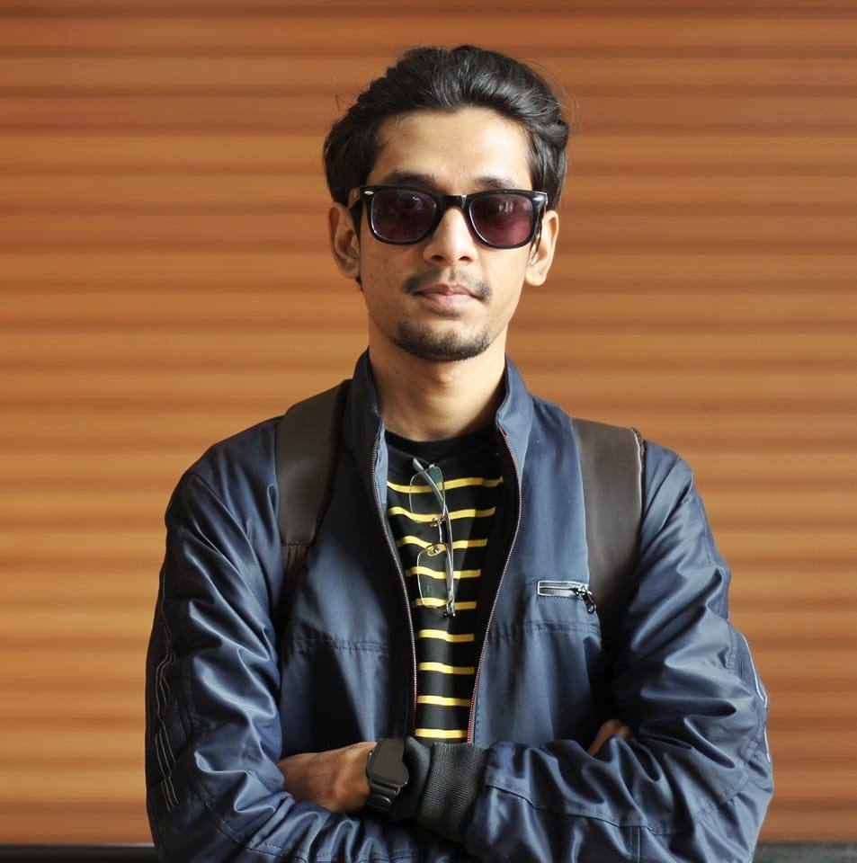

# Musaddiqur Rahman Ovi

### EDUCATION

##### Master of Science (MS) in Statistics | January 2023 – December 2023

Shahjalal University of Science and Technology (SUST), Sylhet

##### Bachelor of Science (Honours) in Statistics | January 2016 – November 2022

Shahjalal University of Science and Technology (SUST), Sylhet

### EXPERIENCE

##### **Data Scientist** | January 2022 – December 2023

Data Science & Business Intelligence Team  
DOER Services Ltd., Dhaka.  
Key Projects: R shiny BI applications

##### **Research Assistant** | September 2020 – September 2023

Biostatistics, Epidemiology and Public Health Research Team  
Department of Statistics, SUST, Sylhet, Bangladesh  
Key Project: Mental Health Conditions of the University Students in Bangladesh

##### **Freelance Data Analyst** | January 2019 to August 2024

Self-employed

### PUBLILCATIONS

- **Ovi, M. R.**, Siddique, M. A. B., Ahammed, T., Chowdhury, M. A. B., & Uddin, M. J. (2024). Assessment of mental wellbeing of university students in Bangladesh using Goldberg’s GHQ-12: A cross-sectional study. Health Science Reports, 7(3). https://doi.org/10.1002/hsr2.1948
- Doby, B. L., Casey, K., Ross-Driscoll, K., **Rahman Ovi, M.**, Hossain Bhuiyea, M. S., Isty, I. A., & Lynch, R. J. (2023). What is visible is fixable: Visual dashboards for multi-domain assessment of organ procurement organization performance. American Journal of Transplantation, 23(11). https://doi.org/10.1016/j.ajt.2023.08.020
- Siddique, M. A. B., **Ovi, M. R.**, Ahammed, T., Chowdhury, M. A. B., & Uddin, M. J. (2022). Mental health knowledge and awareness among university students in Bangladesh. Heliyon, 8(10). https://doi.org/10.1016/j.heliyon.2022.e11084

### R PACKAGE

Ovi, M. R. (2022). bangladesh: Provides Ready to Use Shapefiles for Geographical Map of Bangladesh. In CRAN: Contributed Packages. https://doi.org/10.32614/CRAN.package.bangladesh

### TECH SKILLS

**Proficient**: R programming, Data Analysis, Data Visualization Design, R Shiny  
**Basic**: Docker, SQL, python, GIS, Java, JavaScript

Made using: [postcards](https://cran.r-project.org/web/packages/postcards/index.html)